# Canadian Minimum Stipend Data Analysis

```r
read.csv("SOS_ Minimum Stipend Data Collection - Finalized Information - Machine.csv")->sos

#us Data Source: https://www.nature.com/articles/d41586-022-01392-w
read.csv("Biology Benchmark Comparison - 07-23-2024.csv")->us.data
  #exchange rate
  us.to.cad<-1.38
  #convert from usd to cad internally below


#uk https://www.ukri.org/apply-for-funding/studentships-and-doctoral-training/london-weighting-enhanced-stipends-and-co-funding/
  uk.stipend<-19237
  uk.to.cad<-1.78
  #convert from gbp to cad
  uk.stipend*uk.to.cad->uk.stipend

#NSERC Scholarships
  NSERC.msc<-27000
  NSERC.phd<-40000
```

#Functions

```r
select = dplyr::select #necessary as MASS also has a select function
filter = dplyr::filter

#Standard error of the mean
std <- function(x) sd(x)/sqrt(length(x))


scale_this <- function(x){
  (x - mean(x, na.rm=TRUE)) / sd(x, na.rm=TRUE)
}
```

### NOTES from during converstion to a machine readable datafile

McMaster, both departments, provide “more to offset higher tuition” to the international MSc students, but the amount is unspecified.

# Summary information

There were 140 programs within the final dataset, from 38 Universities. There are 71 MSc and 69 PhD programs. Of all of these different degree programs, 50.7142857% were classified as closest to Ecology, while 49.2857143% are in Physics.

Mean domestic tuition was 5824.5582857CAD, median 6240.165CAD. Mean international tuition was 1.5408013^{4}CAD, median 1.497777^{4}CAD. Mean domestic fees were 1667.0457576CAD, international mean 2264.8789394CAD. Total tuition and fees domestic mean is 7396.3442857CAD, while international total was 1.7560024^{4}CAD.

Of the 140 programs within the final dataset, 93 programs have a minimum, while 10 had no information provided that we could access and did not respond to our requests. The average domestic minimum stipend provided was 2.3933189^{4}CAD, median 2.415^{4}CAD. *When support is different than domestic support*, international minimum gross stipend mean is 2.5754566^{4}CAD. Net domestic mean is 1.6674939^{4}CAD while median 1.729052^{4}CAD.

Mean tuition Get score: NA Mean tuition Parse score: NA Mean Stipend Get score: NA Mean Stipend Complete score: NA

Domestic students repay 33.2732171% back to the university in the form of tuition and fees. International students repay 75.9493073% back to the university in the form of tuition and fees.

Mean MBM Shortfall Domestic: -9584.4457851 Mean MBM Shortfall International: -1.6997344^{4}

difference between US and Canada: NA

```r
sos.df <- as.data.frame(sos)
data.class(sos.df$Gross.Stipend)
```

```
## [1] "numeric"
```

```r
data.class(sos.df$Net.Stipend)
```

```
## [1] "numeric"
```

```r
sos.df$endowment <- sos.df$University.Endowment..Millions.of.Dollars.
data.class(sos.df$endowment)
```

```
## [1] "numeric"
```

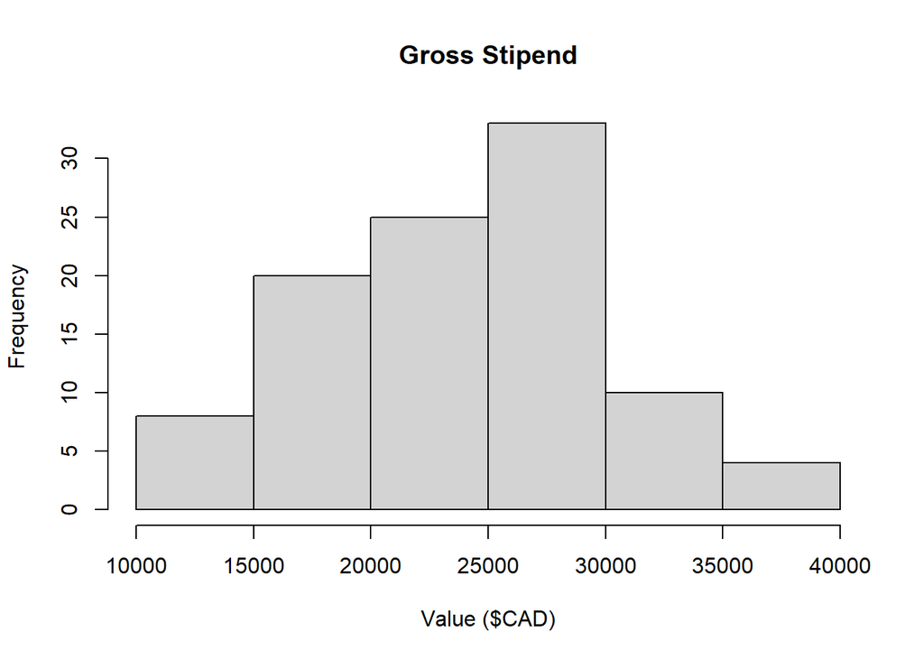

```r
#Histogram of values - visually inspect to see if skewed
histGross <- hist(sos.df$Gross.Stipend,main = "Gross Stipend",xlab = "Value ($CAD)")
```

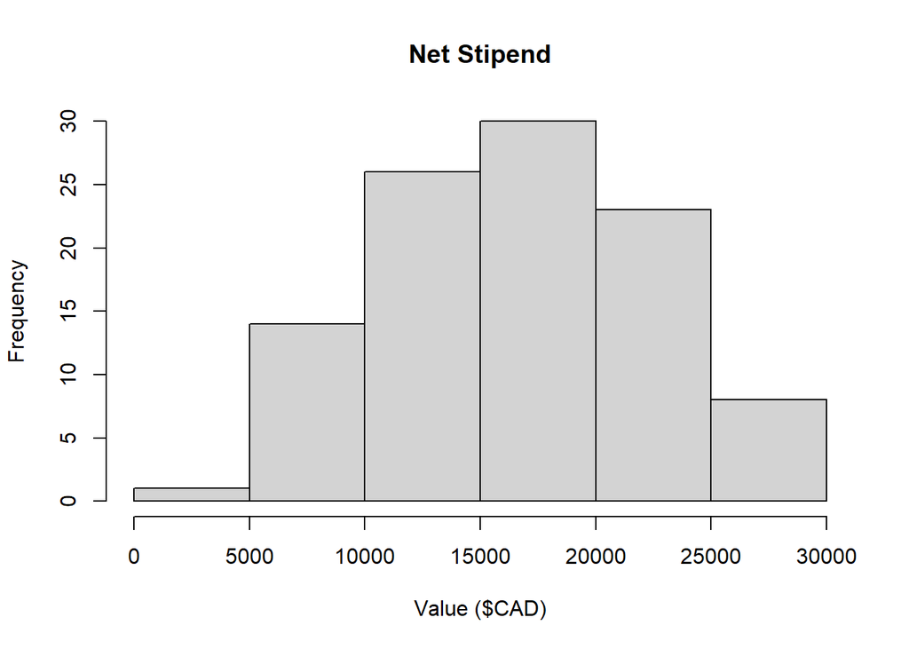

```r
histNet <- hist(sos.df$Net.Stipend,main = "Net Stipend",xlab = "Value ($CAD)")
```

```r
summary(sos.df$Gross.Stipend)
```

```
##    Min. 1st Qu.  Median    Mean 3rd Qu.    Max.    NA's
##   10000   19850   24150   23933   28000   36890      40
```

```r
summary(sos.df$Net.Stipend)
```

```
##    Min. 1st Qu.  Median    Mean 3rd Qu.    Max.    NA's
##    4570   12720   17291   16675   20800   28923      38
```

```r
#Remove NAs
sos.df <- sos.df %>%
  dplyr::filter(!is.na(Gross.Stipend))%>%
  dplyr::filter(!is.na(Net.Stipend))

summary(sos.df$Gross.Stipend)
```

```
##    Min. 1st Qu.  Median    Mean 3rd Qu.    Max.
##   10000   19850   24150   23933   28000   36890
```

```r
summary(sos.df$Net.Stipend)
```

```
##    Min. 1st Qu.  Median    Mean 3rd Qu.    Max.
##    4570   12711   17125   16588   20640   28923
```

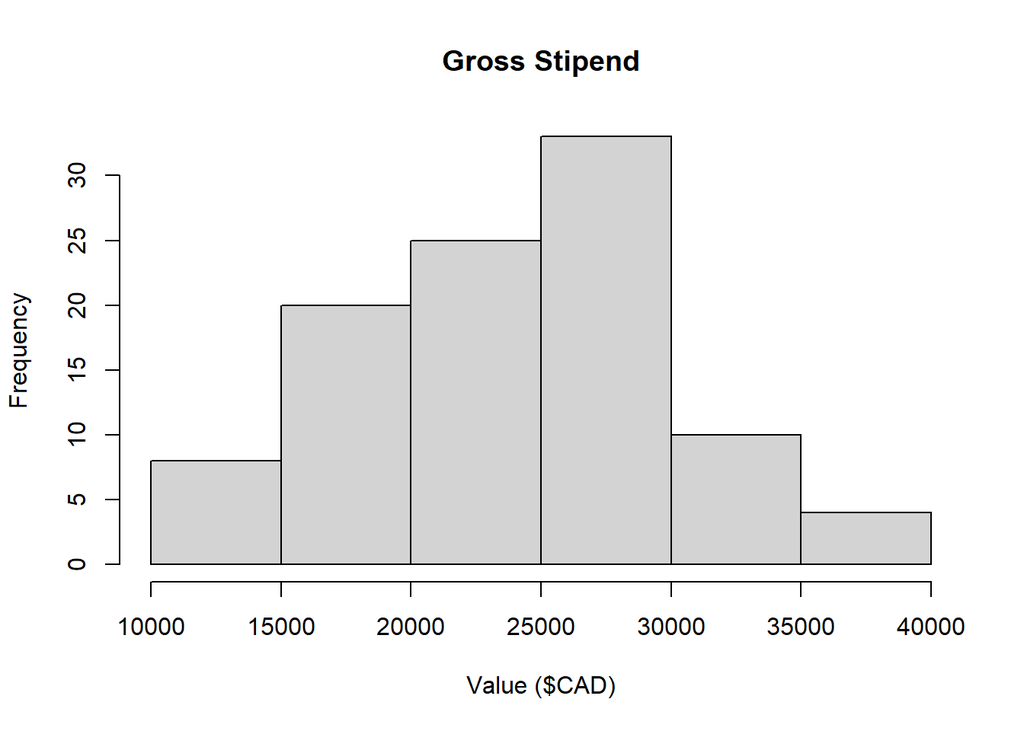

```r
#Histogram of values
histGross <- hist(sos.df$Gross.Stipend,main = "Gross Stipend",xlab = "Value ($CAD)")
```

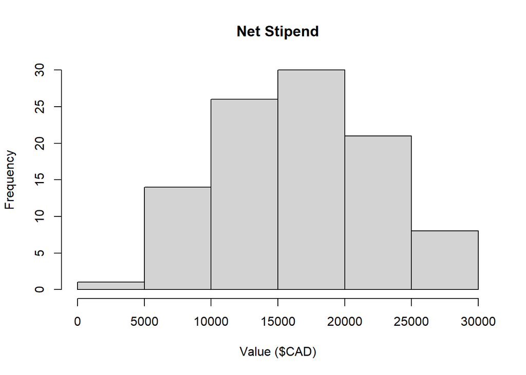

```r
histNet <- hist(sos.df$Net.Stipend,main = "Net Stipend",xlab = "Value ($CAD)")
```

```r
#Scale stipend
sos.df<- sos.df %>%
  mutate(scaledGrossStipend = scale(Gross.Stipend, center = TRUE, scale = TRUE),
         scaledNetStipend = scale(Net.Stipend, center = TRUE, scale = TRUE))

summary(sos.df$scaledGrossStipend)
```

```
##        V1
##  Min.   :-2.33983
##  1st Qu.:-0.68570
##  Median : 0.03641
##  Mean   : 0.00000
##  3rd Qu.: 0.68295
##  Max.   : 2.17587
```

```r
sd(sos.df$scaledGrossStipend)
```

```
## [1] 1
```

```r
summary(sos.df$scaledNetStipend)
```

```
##        V1
##  Min.   :-2.10819
##  1st Qu.:-0.68009
##  Median : 0.09418
##  Mean   : 0.00000
##  3rd Qu.: 0.71061
##  Max.   : 2.16363
```

```r
sd(sos.df$scaledNetStipend)
```

```
## [1] 1
```

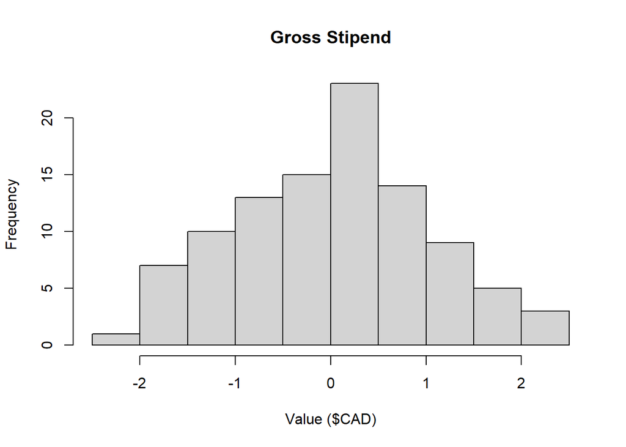

```r
#Histogram of values - visually inspect to see if skewed
histGrossscaled <- hist(sos.df$scaledGrossStipend,main = "Gross Stipend",xlab = "Value ($CAD)")
```

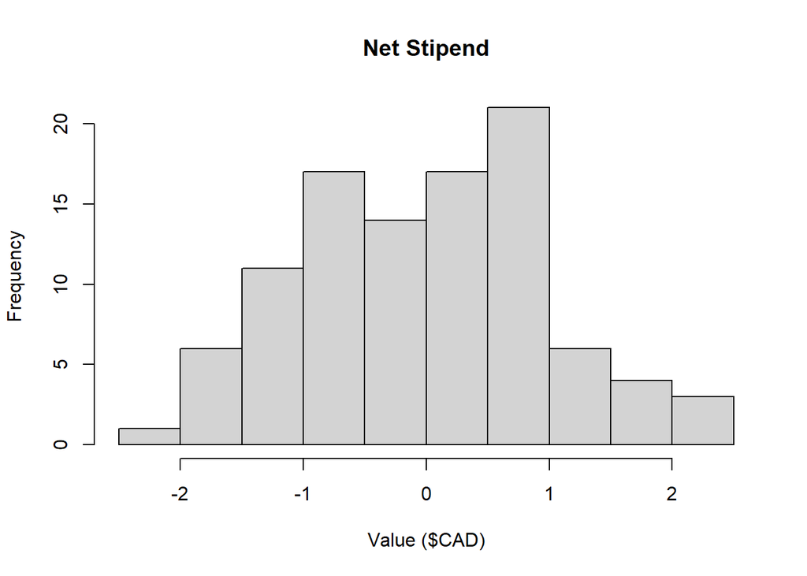

```r
histNetscaled <- hist(sos.df$scaledNetStipend,main = "Net Stipend",xlab = "Value ($CAD)")
```

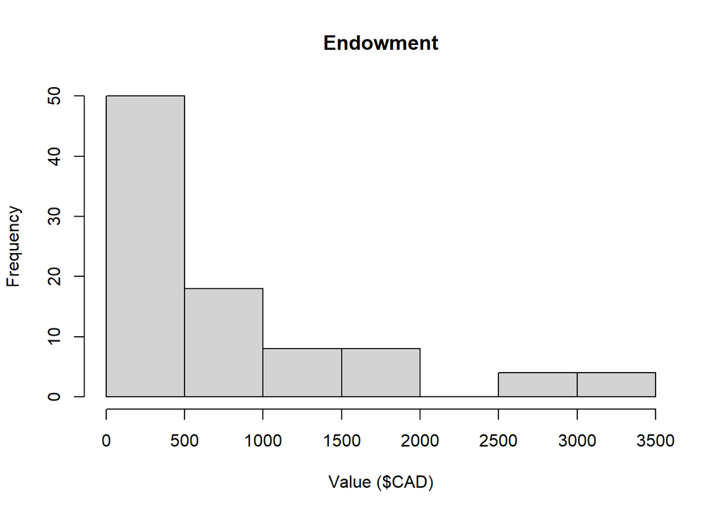

```r
#Endowment
histEndow <- hist(sos.df$endowment,main = "Endowment",xlab = "Value ($CAD)") #highly skewed
```

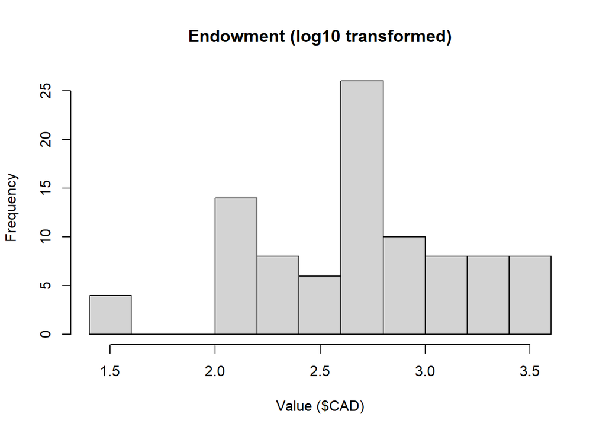

```r
#Log-transform
sos.df<- sos.df %>%
  mutate(logEndowment = log10(endowment))

histlogEndow <- hist(sos.df$logEndowment,main = "Endowment (log10 transformed)",xlab = "Value ($CAD)")
```

#Plots for the paper.

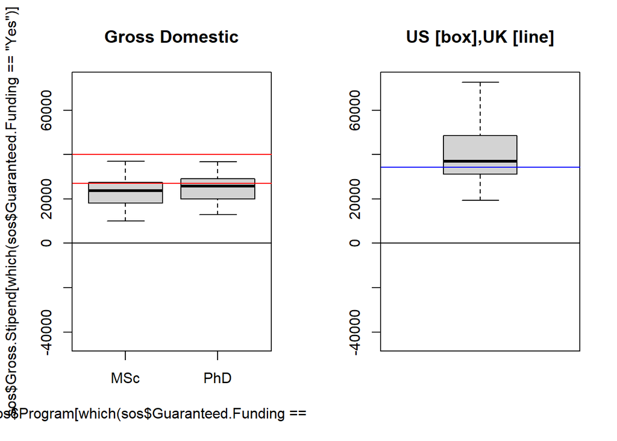

```r
# PhD vs. MSc
  par(mfcol=c(1,2))
      #setting up a stable y to maintain through various plots
        ylimits<-c(min(c(sos$Net.domestic...MBM.Threshold..2024.,
                         {us.data$Annual.guaranteed.salary-us.data$MIT.Living.Wage..1.adult..0.children.}*us.to.cad
                         ),
              na.rm=T),
                   max(c(sos$Gross.Stipend,
                         {us.data$Annual.guaranteed.salary}*us.to.cad,
                         uk.stipend,
                         uk.stipend),
              na.rm=T)
                   )

  ## Gross Stipend (Domestic) Boxplots
    boxplot(sos$Gross.Stipend[which(sos$Guaranteed.Funding == "Yes")] ~ sos$Program[which(sos$Guaranteed.Funding == "Yes")],
            ylim=ylimits,
            main="Gross Domestic")
    abline(h=0,col="black")
    abline(h=c(NSERC.msc,NSERC.phd),col="red")

    boxplot(us.data$Annual.guaranteed.salary*us.to.cad,
            ylim=ylimits,
            main="US [box],UK [line]")
    abline(h=uk.stipend,col="blue")
    abline(h=0,col="black")
```

Left panel is Canadian domestic students gross minimum stipends, two red are for federally supported students, higher is PhD, lower MSc. Right is for international comparisons. Blue is UK, which provides a single stipend amount (exception: London) for the entire funding system.

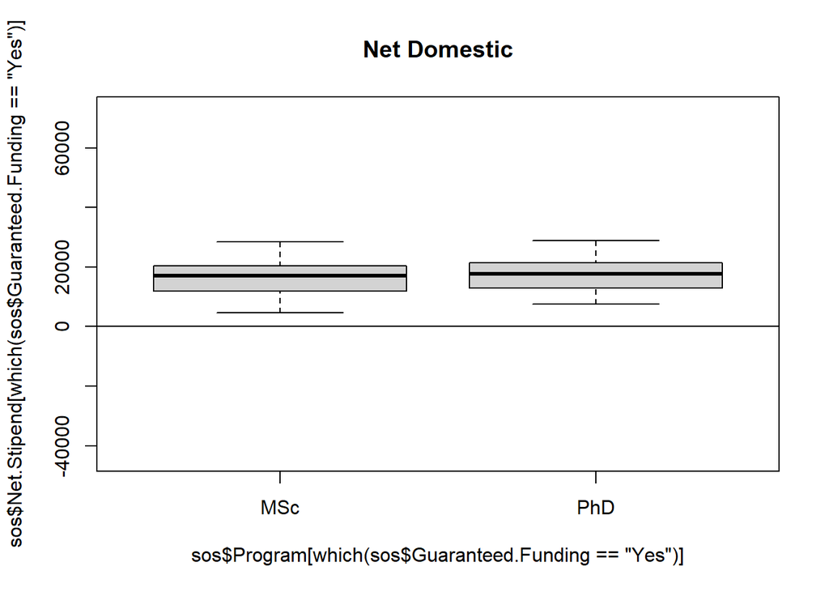

```r
  ## Net Stipend (Domestic) Boxplots
    boxplot(sos$Net.Stipend[which(sos$Guaranteed.Funding == "Yes")] ~ sos$Program[which(sos$Guaranteed.Funding == "Yes")],
            ylim=ylimits,
            main="Net Domestic")
    abline(h=0,col="black")
```

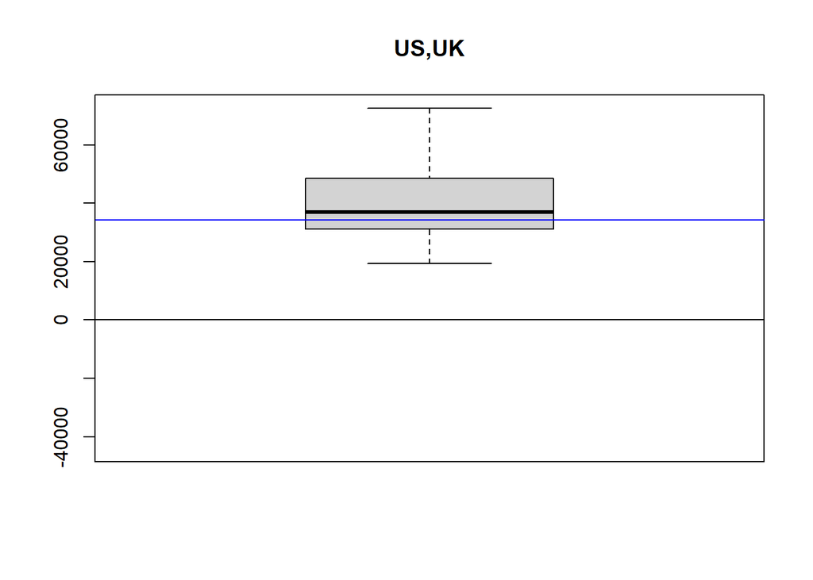

```r
    boxplot(us.data$Annual.guaranteed.salary*us.to.cad,
            ylim=ylimits,
            main="US,UK")
    abline(h=0,col="black")
    abline(h=uk.stipend,col="blue")
```

Same labeling conventions as above.

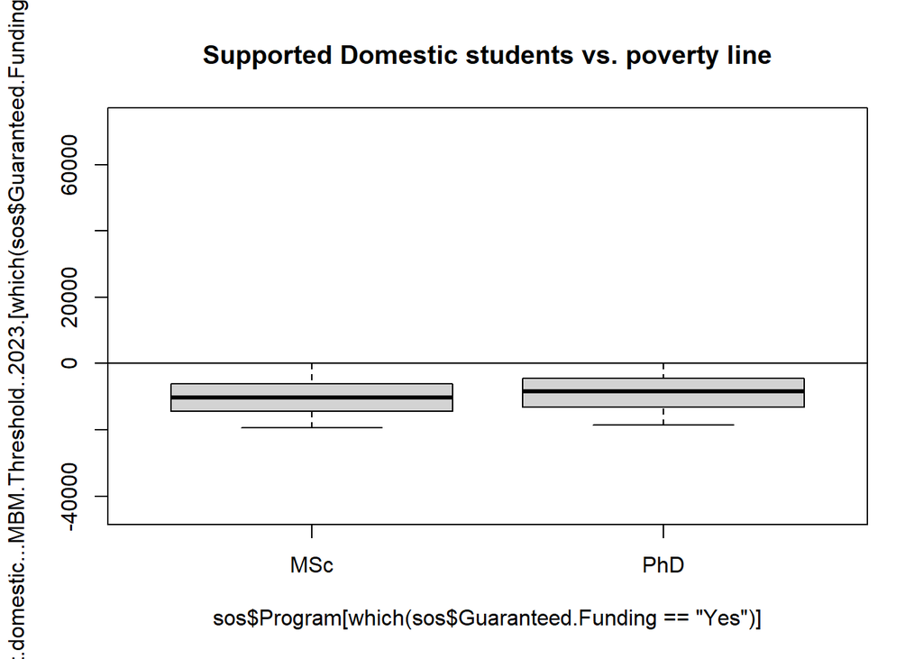

```r
  ## Vs. poverty threshold (Domestic)
  par(mfcol=c(1,1))

    boxplot(sos$Net.domestic...MBM.Threshold..2023.[which(sos$Guaranteed.Funding == "Yes")] ~ sos$Program[which(sos$Guaranteed.Funding == "Yes")],
            ylim=ylimits,
            main="Supported Domestic students vs. poverty line")
        abline(h=0)
```

Same labeling conventions as above. This has had the Market Basket Metric removed, as a measure of poverty provided by the government. Again, this is only for students with support. All students in departments without a minimum graduate stipend have been removed. ## Supplemental figures

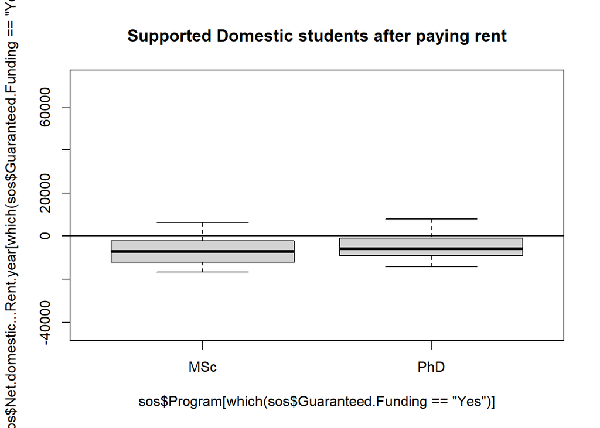

```r
  ## Vs. poverty threshold (Domestic)
  par(mfcol=c(1,1))

    boxplot(sos$Net.domestic...Rent.year[which(sos$Guaranteed.Funding == "Yes")] ~ sos$Program[which(sos$Guaranteed.Funding == "Yes")],
            ylim=ylimits,
            main="Supported Domestic students after paying rent")
        abline(h=0)
```

This is just after paying an average rent for their area and tuition and fees. No food, for example, is included.

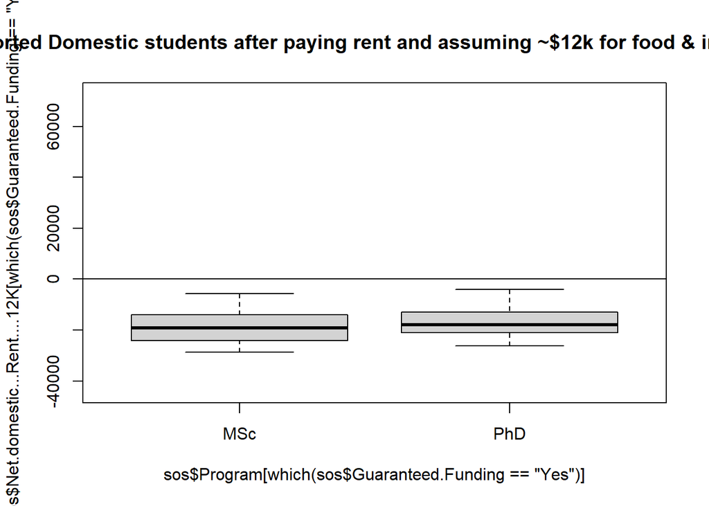

```r
  ## Vs. poverty threshold (Domestic)
  par(mfcol=c(1,1))

    boxplot(sos$Net.domestic...Rent....12K[which(sos$Guaranteed.Funding == "Yes")] ~ sos$Program[which(sos$Guaranteed.Funding == "Yes")],
            ylim=ylimits,
            main="Supported Domestic students after paying rent and assuming ~$12k for food & incidentals")
        abline(h=0)
```

```r
plot(sos$University.Endowment..Millions.of.Dollars.[which(sos$Example.Department == "Physics")],
     sos$Net.Stipend[which(sos$Example.Department == "Physics")],
     pch=16,
     col="purple",
     ylim=c(0,max(sos$Net.Stipend,na.rm=T)),
     main="Univ. Endowment vs. Net Stipends")
points(sos$University.Endowment..Millions.of.Dollars.[which(sos$Example.Department == "Biological Sciences - Ecology")],
     sos$Net.Stipend[which(sos$Example.Department == "Biological Sciences - Ecology")],
     pch=15,
     col="forestgreen")
cor.test(sos$University.Endowment..Millions.of.Dollars.,
     sos$Net.Stipend,use="complete.obs")
```

```
##
##  Pearson's product-moment correlation
##
## data:  sos$University.Endowment..Millions.of.Dollars. and sos$Net.Stipend
## t = 7.5965, df = 92, p-value = 2.465e-11
## alternative hypothesis: true correlation is not equal to 0
## 95 percent confidence interval:
##  0.4784279 0.7314616
## sample estimates:
##       cor
## 0.6208602
```

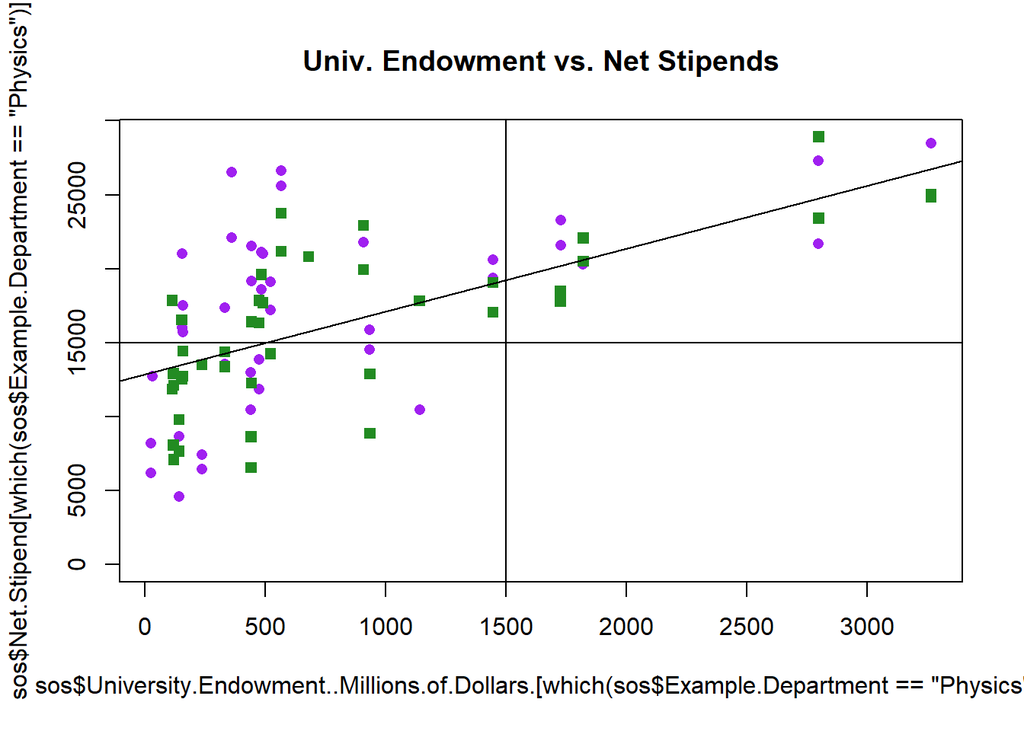

```r
# Line of correlation
  lm(sos$Net.Stipend[which(sos$Example.Department == "Biological Sciences - Ecology")] ~ sos$University.Endowment..Millions.of.Dollars.[which(sos$Example.Department == "Biological Sciences - Ecology")] )->lm.end
  abline(lm.end)

#chi sq tests
    #median(sos$University.Endowment..Millions.of.Dollars.,na.rm=T)->ue
    #median(sos$Net.Stipend,na.rm=T)->ns
  # or
    1500->ue
    15000->ns
abline(v=ue)
abline(h=ns)
```

```r
length(which(sos$University.Endowment..Millions.of.Dollars. >= ue &
               sos$Net.Stipend >= ns))->up.right
length(which(sos$University.Endowment..Millions.of.Dollars. < ue &
               sos$Net.Stipend >= ns))->up.left
length(which(sos$University.Endowment..Millions.of.Dollars. < ue &
               sos$Net.Stipend < ns))->down.left
length(which(sos$University.Endowment..Millions.of.Dollars. >= ue &
               sos$Net.Stipend < ns))->down.right
# table
as.table(rbind(c(up.left,up.right),c(down.left,down.right)))->table
chisq.test(table)
```

```
##
##  Pearson's Chi-squared test with Yates' continuity correction
##
## data:  table
## X-squared = 10.608, df = 1, p-value = 0.001126
```

```r
#Q-Q Plots for scaled Gross Stipend

  data.class(sos.df$Gross.Stipend)
```

```
## [1] "numeric"
```

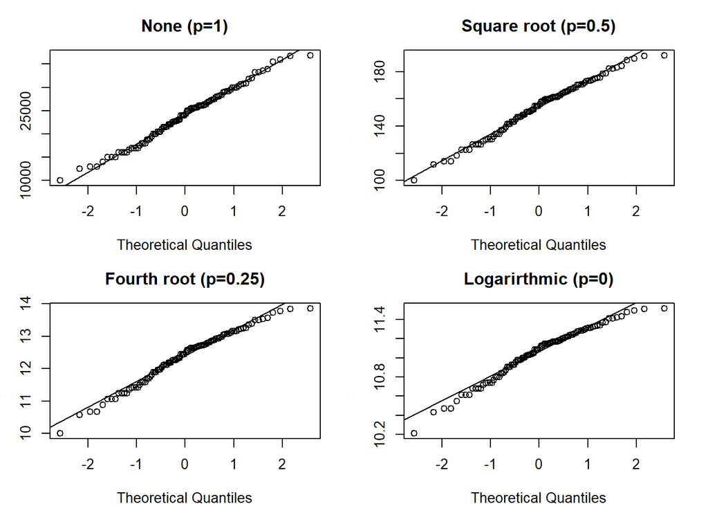

```r
  sos.df$Gross.Stipend.SQ <- sqrt(sos.df$Gross.Stipend)
  sos.df$Gross.Stipend.SQ4 <- sos.df$Gross.Stipend^(0.25)
  sos.df$Gross.Stipend.Log <- log(sos.df$Gross.Stipend)+1


  op<-par(mfrow=c(2,2), mar=c(4,3,3,2))
  qqnorm(sos.df$Gross.Stipend, main="None (p=1)")
  qqline(sos.df$Gross.Stipend)
  qqnorm(sos.df$Gross.Stipend.SQ, main="Square root (p=0.5)")
  qqline(sos.df$Gross.Stipend.SQ)
  qqnorm(sos.df$Gross.Stipend.SQ4,main="Fourth root (p=0.25)")
  qqline(sos.df$Gross.Stipend.SQ4)
  qqnorm(sos.df$Gross.Stipend.Log,main="Logarirthmic (p=0)")
  qqline(sos.df$Gross.Stipend.Log)
```

```r
  par(op)


#Q-Q Plots for scaled Net Stipend

  data.class(sos.df$Net.Stipend)
```

```
## [1] "numeric"
```

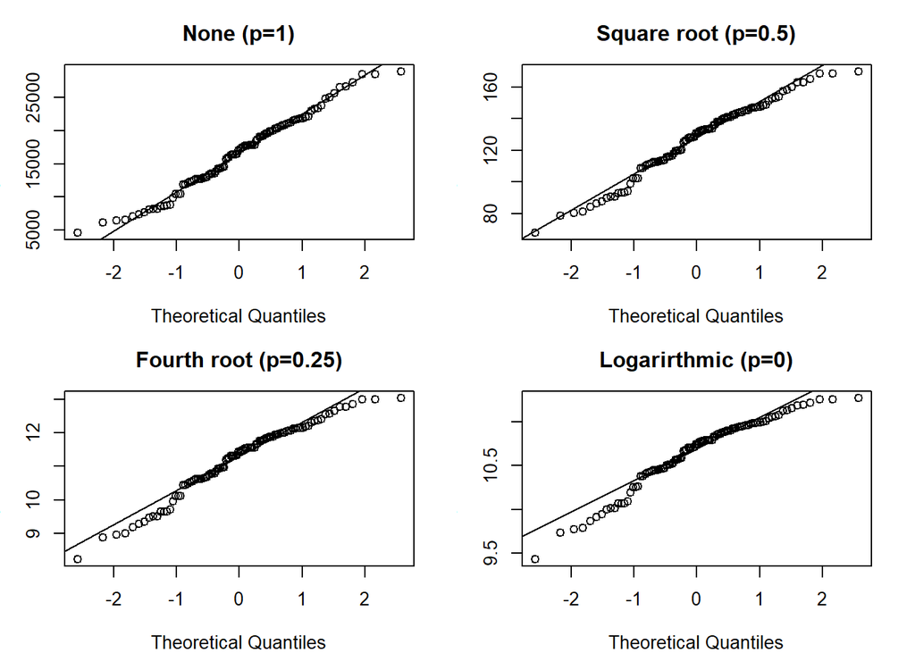

```r
  sos.df$Net.Stipend.SQ <- sqrt(sos.df$Net.Stipend)
  sos.df$Net.Stipend.SQ4 <- sos.df$Net.Stipend^(0.25)
  sos.df$Net.Stipend.Log <- log(sos.df$Net.Stipend)+1


  op<-par(mfrow=c(2,2), mar=c(4,3,3,2))
  qqnorm(sos.df$Net.Stipend, main="None (p=1)")
  qqline(sos.df$Net.Stipend)
  qqnorm(sos.df$Net.Stipend.SQ, main="Square root (p=0.5)")
  qqline(sos.df$Net.Stipend.SQ)
  qqnorm(sos.df$Net.Stipend.SQ4,main="Fourth root (p=0.25)")
  qqline(sos.df$Net.Stipend.SQ4)
  qqnorm(sos.df$Net.Stipend.Log,main="Logarirthmic (p=0)")
  qqline(sos.df$Net.Stipend.Log)
```

```r
  par(op)



#Filter NA endowment data
sos.df <- sos.df %>%
    filter(!is.na(endowment)) %>%
    collect()%>%
    filter(Guaranteed.Funding == "Yes")

#Number of data rows remaining
  nrow(sos.df)
```

```
## [1] 82
```

```r
  n_distinct(sos.df$University)
```

```
## [1] 25
```

```r
  sos.datasummary <- sos.df %>%
  group_by(Province) %>%
    summarise(nrecords = length (University))
  sos.datasummary
```

| Province | nrecords |
| --- | --- |
| AB | 4 |
| BC | 12 |
| MB | 4 |
| NB | 4 |
| NL | 4 |
| NS | 4 |
| ON | 36 |
| QC | 12 |
| SK | 2 |

```r
#GLMM Net
  NMSm1 <- lmer(Net.Stipend ~
                    logEndowment
                    + Program
                    + Example.Department
                    + (1|Province/University),   data = sos.df)
  NMSm1
```

```
## Linear mixed model fit by REML ['lmerModLmerTest']
## Formula: Net.Stipend ~ logEndowment + Program + Example.Department + (1 |
##     Province/University)
##    Data: sos.df
## REML criterion at convergence: 1493.689
## Random effects:
##  Groups              Name        Std.Dev.
##  University:Province (Intercept) 3080
##  Province            (Intercept) 1996
##  Residual                        2379
## Number of obs: 82, groups:  University:Province, 25; Province, 9
## Fixed Effects:
##               (Intercept)               logEndowment
##                   -8578.0                     8587.4
##                ProgramPhD  Example.DepartmentPhysics
##                    1829.4                      870.2
```

```r
  summary(NMSm1)
```

```
## Linear mixed model fit by REML. t-tests use Satterthwaite's method [
## lmerModLmerTest]
## Formula: Net.Stipend ~ logEndowment + Program + Example.Department + (1 |
##     Province/University)
##    Data: sos.df
##
## REML criterion at convergence: 1493.7
##
## Scaled residuals:
##      Min       1Q   Median       3Q      Max
## -2.47404 -0.40967  0.00843  0.58446  1.82933
##
## Random effects:
##  Groups              Name        Variance Std.Dev.
##  University:Province (Intercept) 9488650  3080
##  Province            (Intercept) 3984869  1996
##  Residual                        5661384  2379
## Number of obs: 82, groups:  University:Province, 25; Province, 9
##
## Fixed effects:
##                           Estimate Std. Error       df t value Pr(>|t|)
## (Intercept)               -8577.99    4069.26    22.12  -2.108 0.046586 *
## logEndowment               8587.36    1452.82    19.88   5.911 9.04e-06 ***
## ProgramPhD                 1829.35     525.51    54.78   3.481 0.000988 ***
## Example.DepartmentPhysics   870.16     579.14    60.20   1.503 0.138195
## ---
## Signif. codes:  0 '***' 0.001 '**' 0.01 '*' 0.05 '.' 0.1 ' ' 1
##
## Correlation of Fixed Effects:
##             (Intr) lgEndw PrgrPD
## logEndowmnt -0.961
## ProgramPhD  -0.065  0.000
## Exmpl.DprtP -0.067  0.001  0.000
```

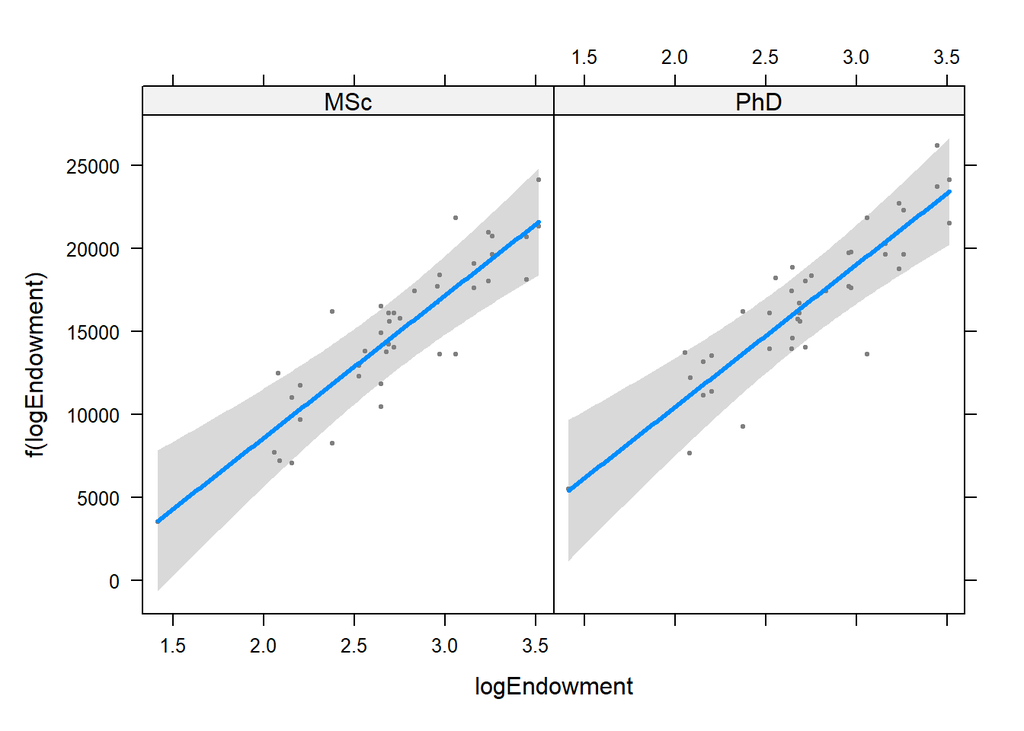

```r
  visreg(NMSm1, "logEndowment", by = "Program")
```

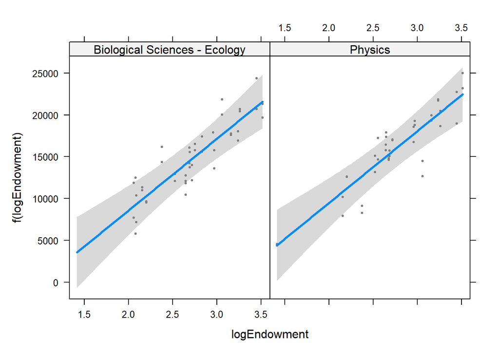

```r
  visreg(NMSm1, "logEndowment", by = "Example.Department")
```

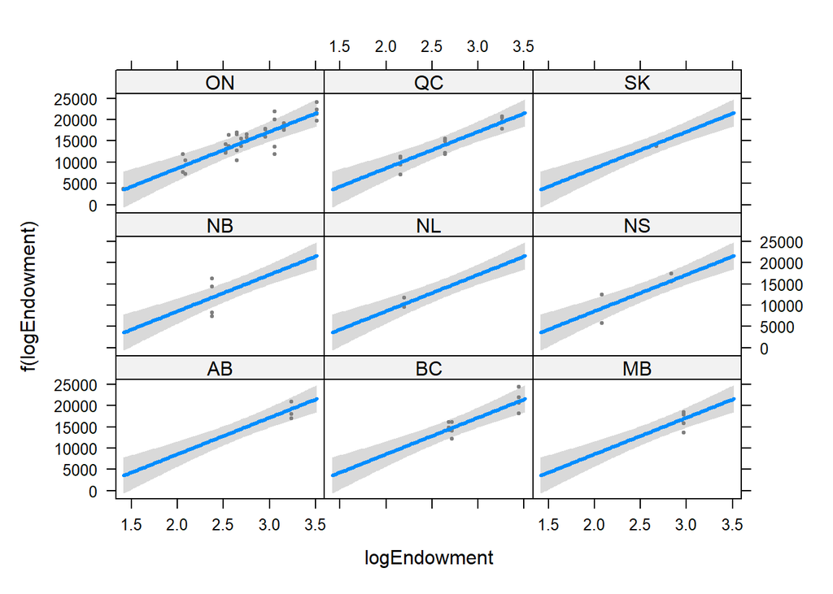

```r
  visreg(NMSm1, "logEndowment", by = "Province")
```

```r
  resid(NMSm1)
```

```
##           1           2           3           4           5           6
##  1572.25385  -257.09914  -297.91023   372.73678 -1192.05764 -2301.41062
##           7           8           9          10          11          12
##  1750.77828  1631.42529  -341.52285  3344.83416 -2933.68694   836.96008
##          13          14          15          16          17          18
##  -754.66000 -2584.01299  1342.17591  1412.82292 -3312.56460 -1141.91759
##          19          20          21          22          23          24
##  1467.27131   987.91832  4352.64947  2523.29649 -3587.01461 -4416.36760
##          25          26          27          28          29          30
##  -681.27748  -815.63047  1414.55843  1380.20544  1665.00366  -164.34933
##          31          32          33          34          35          36
## -3724.18902 -1413.02200  2322.56690  2858.73391   -96.57544  1062.07157
##          37          38          39          40          41          42
##   866.58047  -962.77251  -965.43241  -794.78540   506.40351  -122.94948
##          43          44          45          46          47          48
##  4163.33138  2333.97840 -4057.29270 -5886.64569  -152.05442  -977.87741
##          49          50          51          52          53          54
##  -818.21851  1155.95851  3203.10930 -3469.74369   -65.26133   105.38568
##          55          56          57          58          59          60
##   408.02565  2992.67266 -2138.90308  1031.74393  -272.92685 -1922.27983
##          61          62          63          64          65          66
##  2532.90907   703.55608   711.89632  1458.54333  1028.21988  -801.13310
##          67          68          69          70          71          72
## -1375.56798  2795.07903  1278.09836  1013.74538   198.41428 -1630.93871
##          73          74          75          76          77          78
## -2303.06808 -2051.42107   756.76783  1427.41485  1073.49048  1394.13749
##          79          80          81          82
## -2877.03611  -612.22659  -667.28408  -496.63707
```

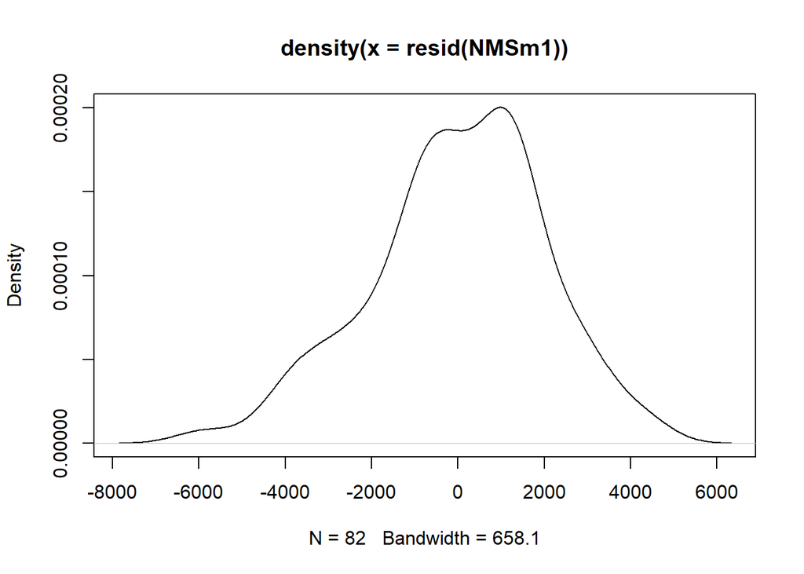

```r
  plot(density(resid(NMSm1)))
```

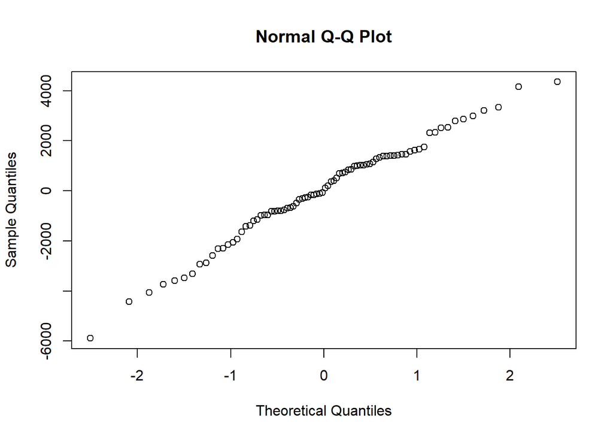

```r
  qqnorm(resid(NMSm1))
```

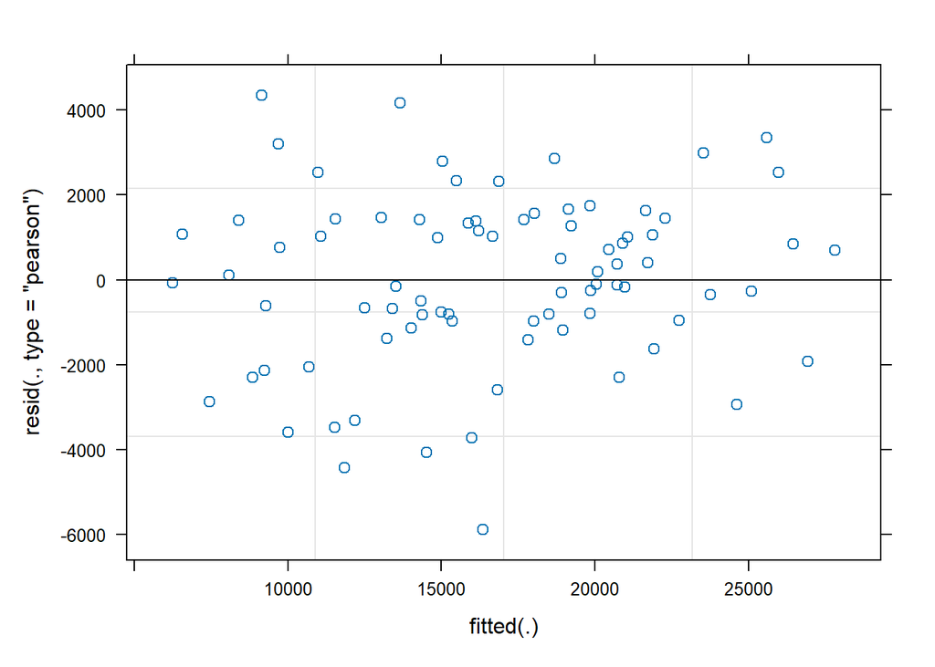

```r
  plot(NMSm1)
```

```r
  AIC(NMSm1)
```

```
## [1] 1507.689
```

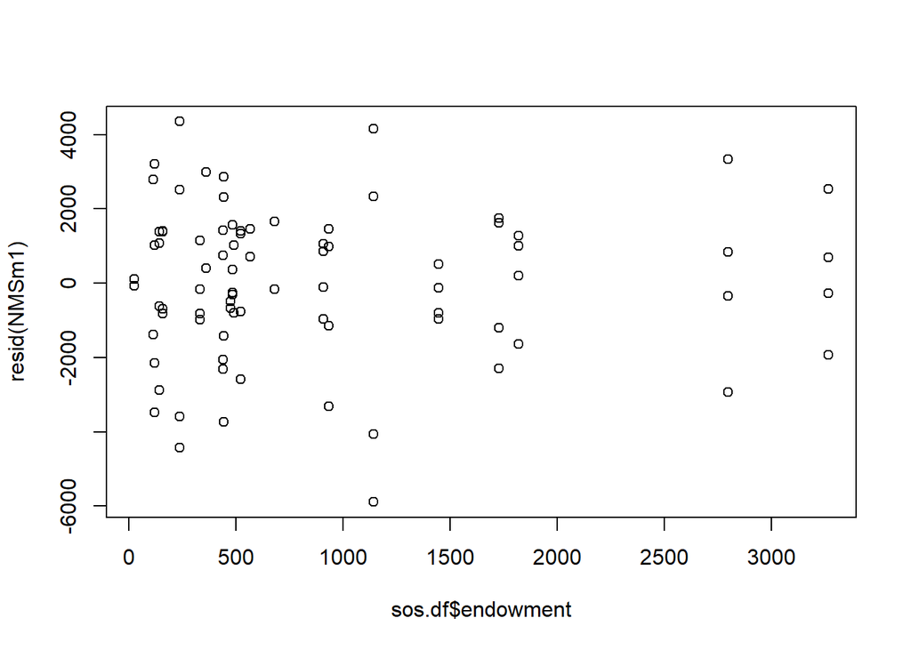

```r
  plot(sos.df$endowment,resid(NMSm1))
```

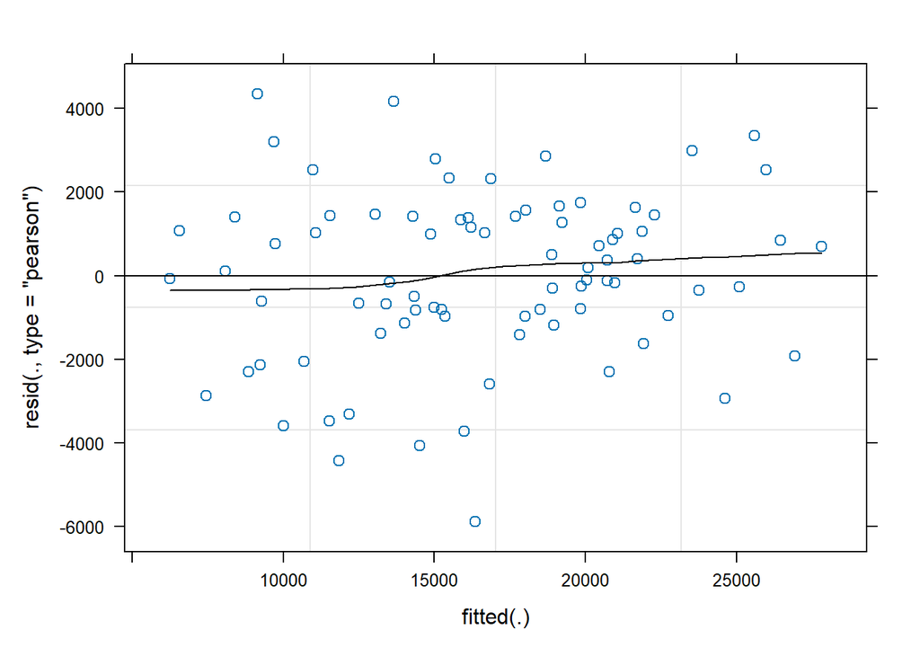

```r
#Fitted vs. Residual w Smooth line
  plot(NMSm1, type=c("p","smooth"), col.line=1)
```

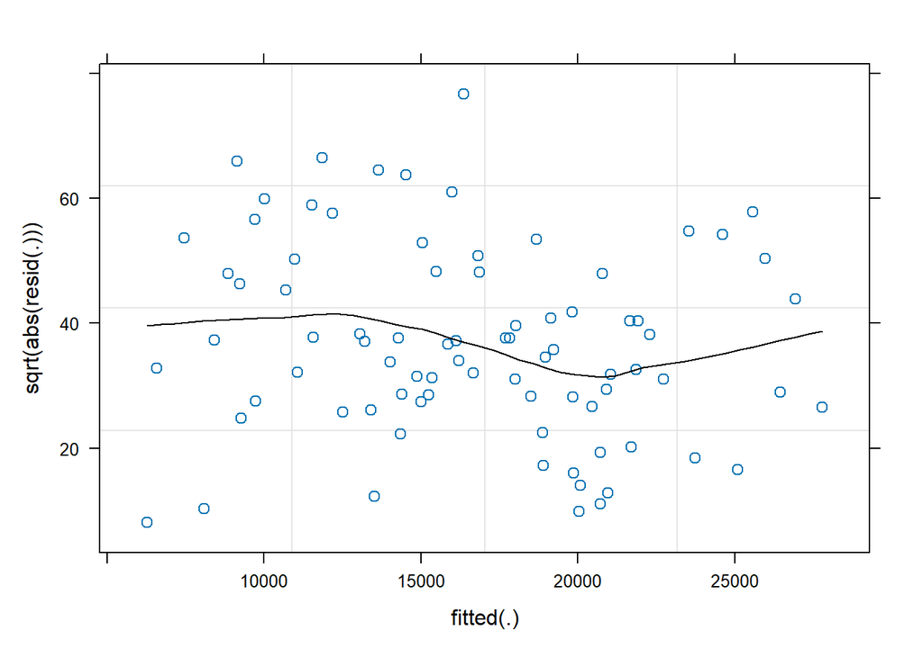

```r
#Scale-Location
  plot(NMSm1,
       sqrt(abs(resid(.)))~fitted(.),
       type=c("p","smooth"), col.line=1)
```

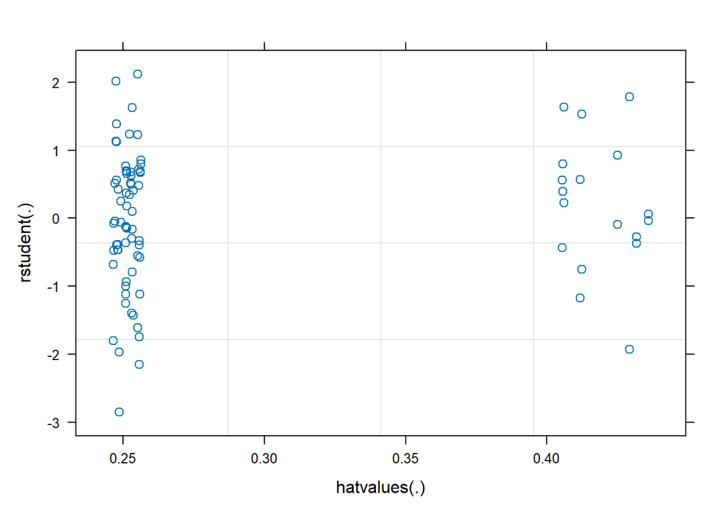

```r
#Residuals v Leveragae
  plot(NMSm1, rstudent(.) ~ hatvalues(.))
```

# OLS Fit for endowment

```r
# Perform OLS regression
model <- lm(Net.Stipend ~ Program + logEndowment, data = sos.df)

# View the summary of the regression
summary(model)
```

```
##
## Call:
## lm(formula = Net.Stipend ~ Program + logEndowment, data = sos.df)
##
## Residuals:
##    Min     1Q Median     3Q    Max
##  -9904  -2882    203   2456  10535
##
## Coefficients:
##              Estimate Std. Error t value Pr(>|t|)
## (Intercept)   -8220.3     2789.1  -2.947  0.00421 **
## ProgramPhD     1829.4      917.4   1.994  0.04960 *
## logEndowment   8752.6      990.6   8.836 2.03e-13 ***
## ---
## Signif. codes:  0 '***' 0.001 '**' 0.01 '*' 0.05 '.' 0.1 ' ' 1
##
## Residual standard error: 4154 on 79 degrees of freedom
## Multiple R-squared:  0.5095, Adjusted R-squared:  0.497
## F-statistic: 41.02 on 2 and 79 DF,  p-value: 6.044e-13
```

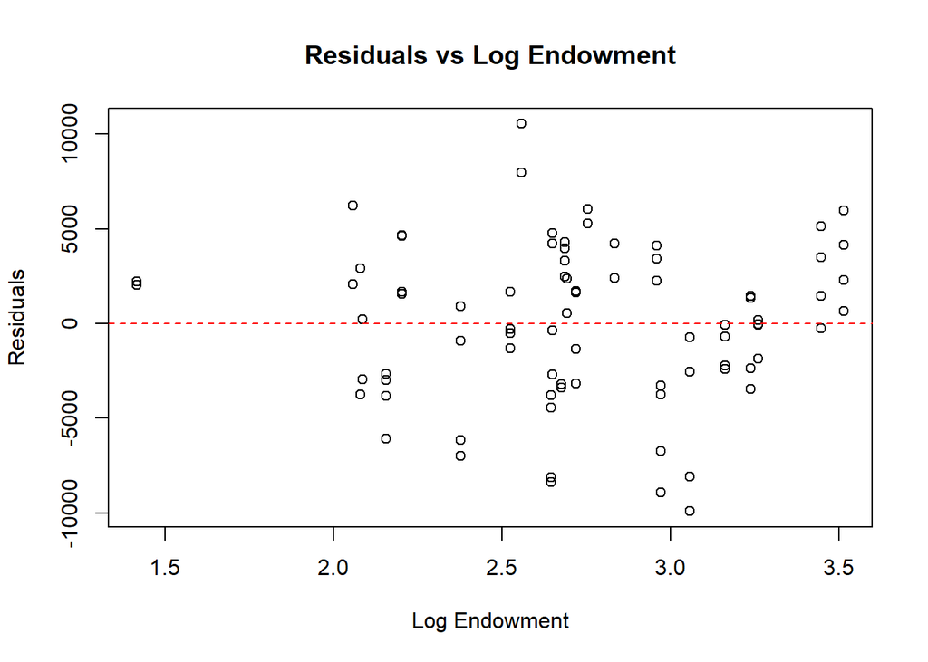

```r
# Plot 1: Residuals vs logEndowment
plot(sos.df$logEndowment, residuals(model),
     xlab = "Log Endowment", ylab = "Residuals",
     main = "Residuals vs Log Endowment")
abline(h = 0, col = "red", lty = 2)
```

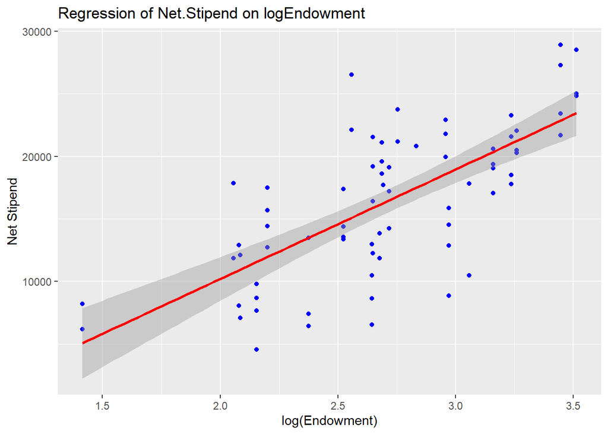

```r
# Create a scatter plot with the regression line
ggplot(sos.df, aes(x = logEndowment, y = Net.Stipend)) +
  geom_point(color = "blue") +  # Plot the data points
  geom_smooth(method = "lm", formula = y ~ x, color = "red") +  # Add the regression line
  labs(title = "Regression of Net.Stipend on logEndowment",
       x = "log(Endowment)",
       y = "Net Stipend")
```